# Deciphering Real vs. Fake News

Camilla Bendetti, Jane Roarty, Max Kent, Flora Fouladi

# Step 1: Process the data

Thank you to our professor Alicia Johnson and Buzzfeed for providing this dataset. The original dataset included columns for the title of the article, the text of the article, the author, the URL, the source, and the real or fake classification.

```r
buzz <- read.csv("https://www.macalester.edu/~ajohns24/data/buzzfeed.csv")
```

### Defining possible predictors

The first step of our classification analysis was to explore possible predictors of fake news. The following are 16 possible predictors.

### Example of our variables in use:

To demonstrate and summarize the definitions of your new predictors, discuss their measurements for one real sample article and one fake sample article of your choosing.

Fake - Article 176

- The number of exclamation points in the article: None
- Title Length: Long
- Whether or not the article was published in the top 4 news sources. We classified these as either cnn, politi, abcn, or the washington post: Not in these sources
- ALL CAPS in title: Yes, HILLARY ON DISABLED CHILDREN
- Look for “…”: None
- ALL CAPS text: Yes
- Article length: Short/average
- If there is an author or not: Yes, there is an author
- Presence of slang: Yes, there are slang words
- Number of times Hillary is mentioned: Many
- Number of times Trump is mentioned: None
- Look for extreme sentiment (packages for sentiment analysis in R: Yes
- Partisanship: Extreme right
- Words and strings after the .com/ or .org/ in the url: Yes
- Mention words like share, twitter, and facebook: Yes
- Presense of asterisks: Yes

Real - Article 171

- The number of exclamation points in the article: None
- Title Length: Short
- Whether or not the article was published in the top 4 news sources. We classified these as either cnn, politi, abcn, or the washington post: Yes, CNN
- ALL CAPS in title: No
- Look for “…”: No
- ALL CAPS text: Yes
- Article length: Short
- If there is an author or not: Yes, there is an author
- Presence of slang: No
- Number of times Hillary is mentioned: Hillary is not mentioned
- Number of times Trump is mentioned: Trump is mentioned
- Look for extreme sentiment (packages for sentiment analysis in R: Yes
- Partisanship: MOderate or Left
- Words and strings after the .com/ or .org/ in the url: No
- Mention words like share, twitter, and facebook: No
- Presense of asterisks: No

### Drawbacks:

One drawback is that when we look for ALL CAPS we sometimes catch acronyms. For example, websites like CNN report are real, but we found many fake articles that use all capital letters in the title. Another drawback is that text analysis is less computationally efficient because we have to scan all the text. We also have to make partial judgments on what is important in writing like punctuation, slang, and sentiment. Additionally, many factors that might be better predictors of whether or not an article is fake are content-based and hard to capture in variables. While we can use the sentiment dictionary to assess the sentiment of the articles, there is much variation in content that goes beyond existing dictionaries.

# Step 2: Constructing the Model

### Building Variables

Counting number of exclamation points in the title

```r
buzz_new <- buzz%>%
  mutate(exclamationpoints_title= str_count(title, pattern = "!"))
```

Counting number of exclamation points in the text

```r
buzz_new <- buzz_new%>%
  mutate(exclamationpoints_text= str_count(title, pattern = "!"))
```

Detects … in the title

```r
buzz_new <- buzz_new%>%
  mutate(ellipsis_title= str_count(title, pattern = "..."))
```

Detects … in the text

```r
buzz_new <- buzz_new%>%
  mutate(ellipsis_text= str_count(text, pattern = "..."))
```

Length of the title, text, number of capital letters in title and text

```r
text_char_len <- str_count(buzz$text)
title_char_len <- str_count(buzz$title)
title_caps <- str_count(buzz$title, "[A-Z]")
text_caps <- str_count(buzz$text, "[A-Z]")

buzz_new <- buzz_new %>%
  mutate(title_length = title_char_len) %>%
  mutate(text_length = text_char_len) %>%
  mutate(title_caps = title_caps) %>%
  mutate(text_caps = text_caps)
```

Number of times social media is mentioned

```r
buzz_new<- buzz_new%>%
  mutate(socialmedia= str_count(text, pattern = "instagram|twitter|facebook"))%>%
  arrange(socialmedia)
```

Number of times Trump is mentioned in the text

```r
buzz_new<- buzz_new%>%
  mutate(Trump= str_count(text, pattern = "Trump"))
```

Number of times Hillary is mentioned in the text

```r
buzz_new<- buzz_new%>%
  mutate(Hillary= str_count(text, pattern= "Hillary"))
```

Detects if there is an author or not

```r
buzz_new<- buzz_new%>%
  mutate(author_na = str_count(authors, pattern = " ")) %>%
  mutate(has_author = (author_na > 0))
```

Top four detection

```r
buzz_new<-buzz_new%>%
  mutate(topfour= str_detect(source, pattern = "cnn|abcn|politi"))

buzz_new_1<- buzz_new%>%
  select(source, topfour)
```

Uses the sentiment dictionary to assess the sentiment of the text of the articles

```r
sentiment <- get_nrc_sentiment(as.character(buzz$text))
buzz_big <- cbind(buzz_new, sentiment)
```

After looking at a summary of the data, we found that there are 91 real articles and 91 fakes articles.

# Creating a TREE model

We used a tree model to select our variables and predict whether or not an article is fake news. We started by including all of our variables as predictors in tree_model, with a cp range of (0.01, 0.5). We selected this range after looking at a bigger range and narrowing after we saw the accuracy leveled off at 0.835. We used the `best` selection function to select a cp value because we wanted to most accurately predict the truthfulness of a source. As we can see from the plot of cp values below, cp values from slightly after 0.04 onward all had the same accuracy values. The `best` function always includes that largest cp value with the best accuracy rate so it will always be the largest value we include since the accuracy leveled off. Because of this, our best cp value is 0.5.

As we can see in the following plot, the only important predictor in the tree with cp 0.5 is whether or not the news source is in the top four news sources.

Since top_four is probably too predictive, however, we built another tree model without this predictor to find the other significant predictors.

### Tree 1

```r
set.seed(253)

tree_model <- train(
  type ~ exclamationpoints_text + exclamationpoints_title + ellipsis_title + ellipsis_text + title_length + text_length + title_caps + text_caps + socialmedia + Trump + Hillary + author_na + has_author+topfour +anger+anticipation+disgust+fear+joy+sadness+surprise+trust+negative+positive,
  data = buzz_big,
  method = "rpart",
  tuneGrid = data.frame(cp = seq(0.01, 0.5, length = 50)),
  trControl = trainControl(method = "cv", number = 10, selectionFunction = "best"),
  metric = "Accuracy",
  na.action = na.omit
)
```

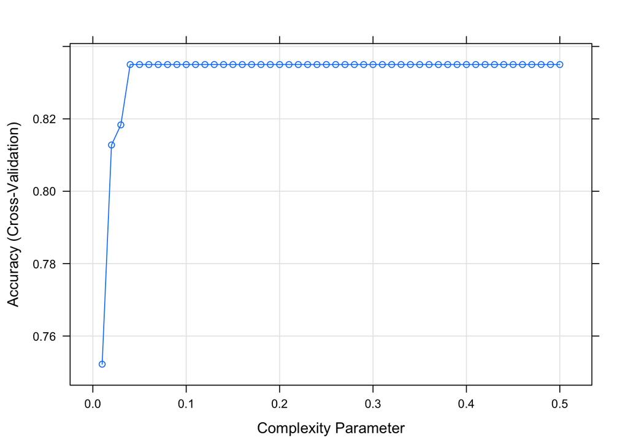

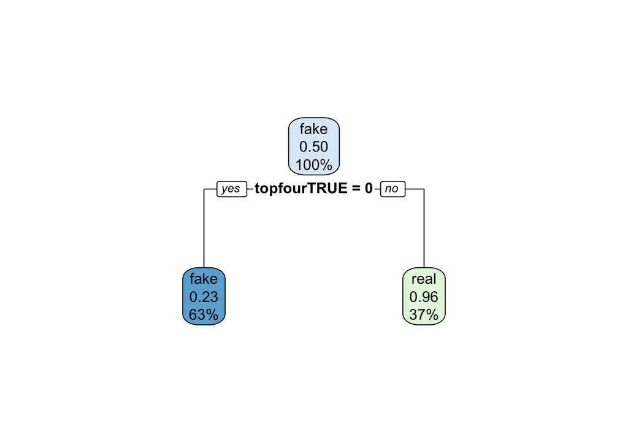

```
##    topfourTRUE     title_caps ellipsis_title   title_length  ellipsis_text
##       43.94692       27.54881       11.15071       11.15071        7.87109
##    text_length
##        7.87109
```

### Tree 2

```r
set.seed(253)

tree_model_2 <- train(
  type ~ exclamationpoints_text + exclamationpoints_title + ellipsis_title + ellipsis_text + title_length + text_length + title_caps + text_caps + socialmedia + Trump + Hillary + author_na + has_author +anger+anticipation+disgust+fear+joy+sadness+surprise+trust+negative+positive,
  data = buzz_big,
  method = "rpart",
  tuneGrid = data.frame(cp = seq(0.01, 0.5, length = 50)),
  trControl = trainControl(method = "cv", number = 10, selectionFunction = "best"),
  metric = "Accuracy",
  na.action = na.omit
)
```

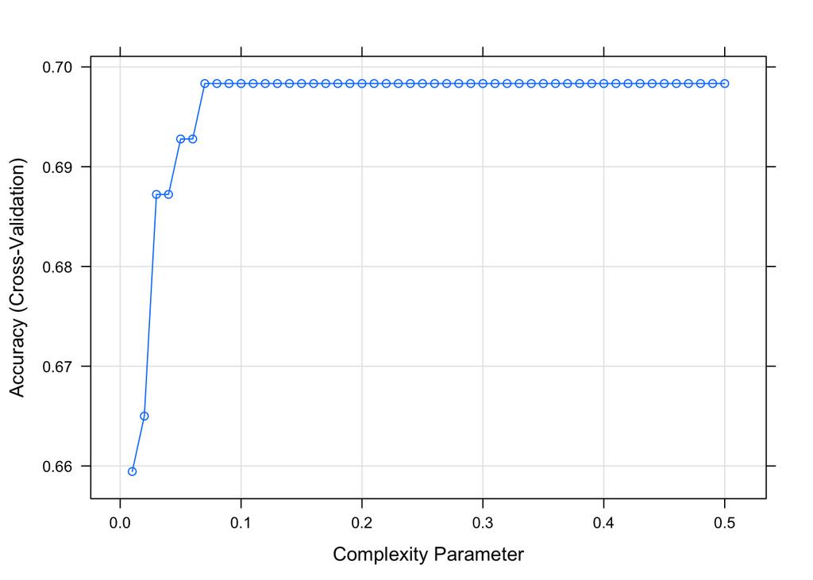

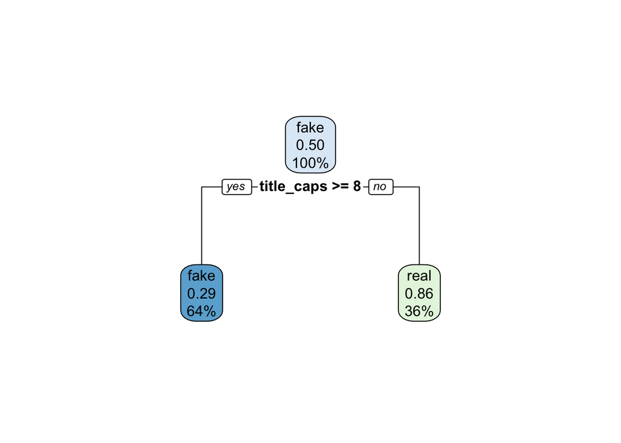

```
##     title_caps ellipsis_title   title_length  ellipsis_text    text_length
##      27.385580      11.203192      11.203192       6.638928       6.638928
##          Trump
##       4.149330
```

```
##   mean(Accuracy)
## 1      0.6962222
```

# Building a FOREST model

### Forest model

```r
set.seed(253)

forest_regression <- train(
  type ~ exclamationpoints_text + exclamationpoints_title + ellipsis_title + ellipsis_text + title_length + text_length + title_caps + text_caps + socialmedia + Trump + Hillary + author_na + has_author+anger+anticipation+disgust+fear+joy+sadness+surprise+trust+negative+positive,
  data = buzz_big,
  method = "rf",
  tuneGrid = data.frame(mtry = seq(1:23)),
  trControl = trainControl(method = "oob"),
  metric = "Accuracy",
  na.action = na.omit
  )
```

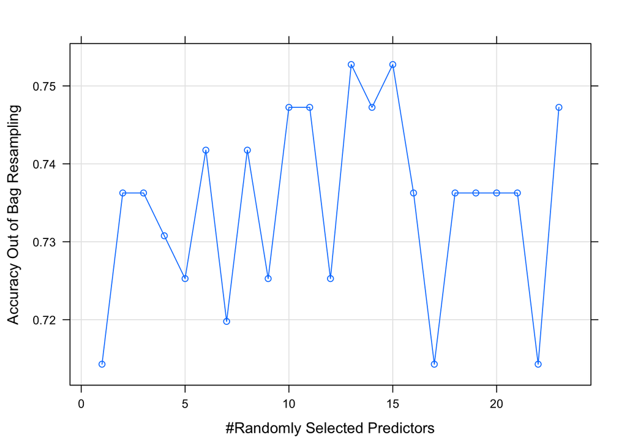

### Confusion matrix

```r
forest_regression$finalModel
```

```
##
## Call:
##  randomForest(x = x, y = y, mtry = param$mtry)
##                Type of random forest: classification
##                      Number of trees: 500
## No. of variables tried at each split: 13
##
##         OOB estimate of  error rate: 25.27%
## Confusion matrix:
##      fake real class.error
## fake   74   17   0.1868132
## real   29   62   0.3186813
```

```r
forest_regression$bestTune
```

```
##    mtry
## 13   13
```

```r
forest_regression$results
```

```
##     Accuracy     Kappa mtry
## 1  0.7142857 0.4285714    1
## 2  0.7362637 0.4725275    2
## 3  0.7362637 0.4725275    3
## 4  0.7307692 0.4615385    4
## 5  0.7252747 0.4505495    5
## 6  0.7417582 0.4835165    6
## 7  0.7197802 0.4395604    7
## 8  0.7417582 0.4835165    8
## 9  0.7252747 0.4505495    9
## 10 0.7472527 0.4945055   10
## 11 0.7472527 0.4945055   11
## 12 0.7252747 0.4505495   12
## 13 0.7527473 0.5054945   13
## 14 0.7472527 0.4945055   14
## 15 0.7527473 0.5054945   15
## 16 0.7362637 0.4725275   16
## 17 0.7142857 0.4285714   17
## 18 0.7362637 0.4725275   18
## 19 0.7362637 0.4725275   19
## 20 0.7362637 0.4725275   20
## 21 0.7362637 0.4725275   21
## 22 0.7142857 0.4285714   22
## 23 0.7472527 0.4945055   23
```

### Variable importance

```r
variable_importance <- data.frame(importance(forest_regression$finalModel)) %>%
  mutate(predictor = rownames(.))

variable_importance
```

```
##    MeanDecreaseGini               predictor
## 1          1.367020  exclamationpoints_text
## 2          1.546702 exclamationpoints_title
## 3          2.854600          ellipsis_title
## 4          4.027221           ellipsis_text
## 5          4.471473            title_length
## 6          3.847858             text_length
## 7         27.295233              title_caps
## 8          4.147633               text_caps
## 9          1.112268             socialmedia
## 10         3.256606                   Trump
## 11         3.092509                 Hillary
## 12         5.071969               author_na
## 13         2.523353          has_authorTRUE
## 14         2.122467                   anger
## 15         3.841887            anticipation
## 16         3.676910                 disgust
## 17         2.009430                    fear
## 18         2.191651                     joy
## 19         2.194063                 sadness
## 20         1.688239                surprise
## 21         3.053454                   trust
## 22         2.388431                negative
## 23         2.703990                positive
```

Arrange predictors by importance (most to least)

```r
variable_importance %>%
  arrange(desc(MeanDecreaseGini)) %>%
  head(9)
```

```
##   MeanDecreaseGini     predictor
## 1        27.295233    title_caps
## 2         5.071969     author_na
## 3         4.471473  title_length
## 4         4.147633     text_caps
## 5         4.027221 ellipsis_text
## 6         3.847858   text_length
## 7         3.841887  anticipation
## 8         3.676910       disgust
## 9         3.256606         Trump
```

Arrange predictors by importance (least to most)

```r
variable_importance %>%
  arrange(MeanDecreaseGini) %>%
  head()
```

```
##   MeanDecreaseGini               predictor
## 1         1.112268             socialmedia
## 2         1.367020  exclamationpoints_text
## 3         1.546702 exclamationpoints_title
## 4         1.688239                surprise
## 5         2.009430                    fear
## 6         2.122467                   anger
```

### Testing Accuracy

```r
forest_regression$results%>%
  summarize(mean(Accuracy))
```

```
##   mean(Accuracy)
## 1      0.7348304
```

```r
tree_model_2$results%>%
  summarize(mean(Accuracy))
```

```
##   mean(Accuracy)
## 1      0.6962222
```

# Step 3: Summarize

Social media was not as useful as we thought it might be. The social media predictor is counting the number of times “twitter”, “Instagram”, and “Facebook” are included as text in the article. However, our code does not include the mentions when those words are used in buttons. For example, some articles prompt their readers to share the article on social media and if this is through a button, our code will not catch the mention.

### Plots

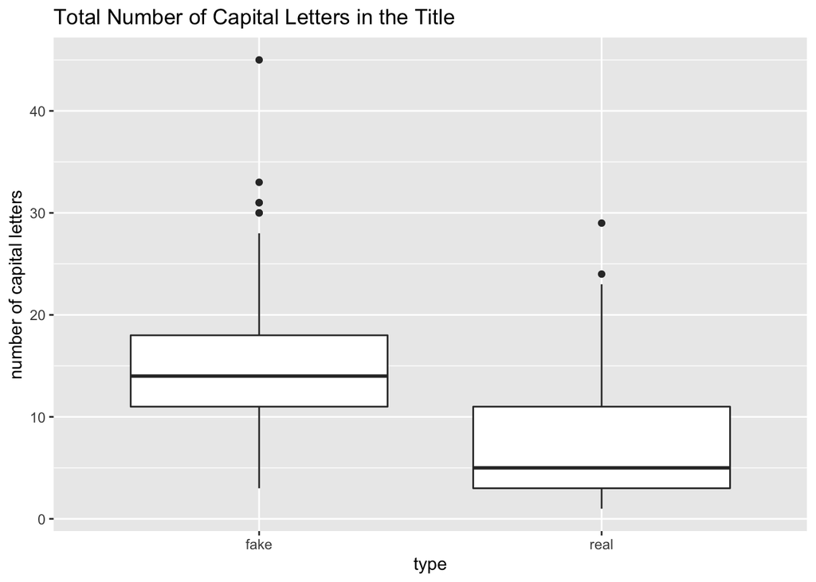

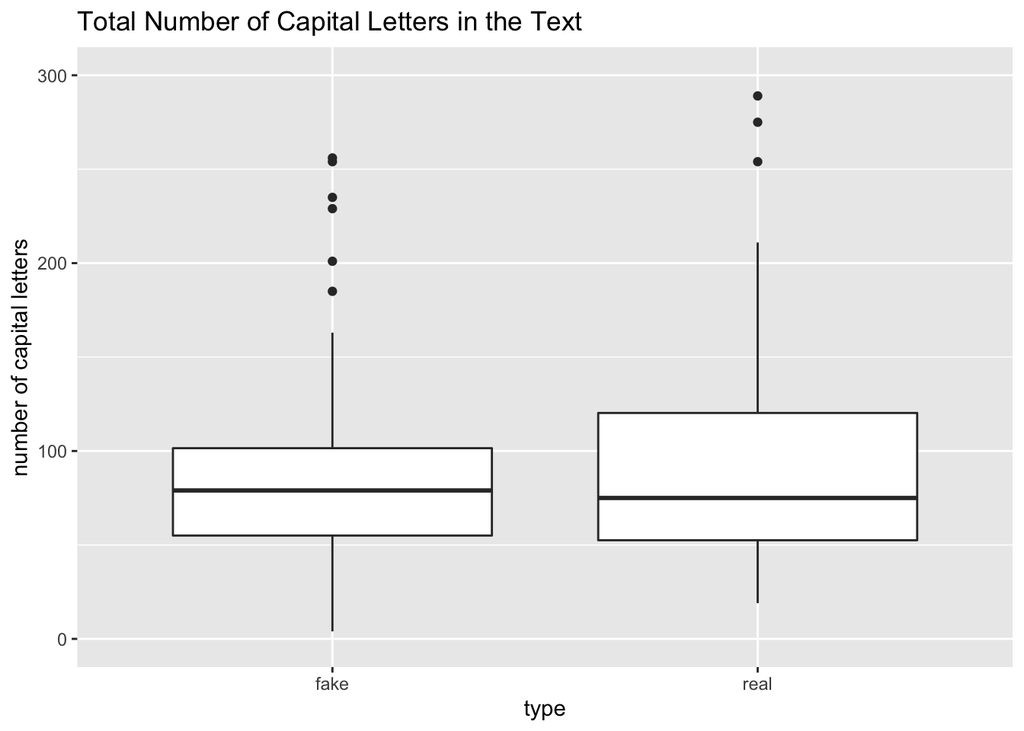

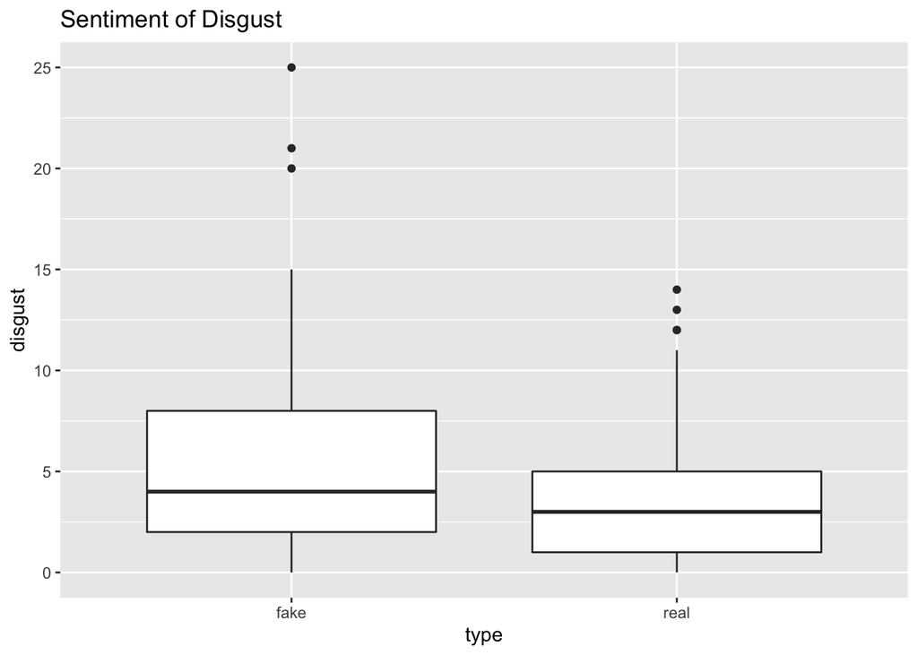

# Step 4: Contributions

All members of the group collaboratively came up with the variables, explanations, and conclusions. We split up making new predictors and wrote the analysis and summary together. All members contributed equally to the project.